# ADS Project 1

jacquelyn blum JEB2266

February 5, 2020

**Is pop music getting more complicated?**

First, load in the lyrics for 100,000 songs.

```r
### 100,000 Song Lyrics
lyrics <- read.csv("lyrics.csv")
```

I just want to focus on pop music here, so I’m going to subset the data and pull out everything that’s in the “Pop” genre.

```r
#narrow the data down to pop music
lyrics_pop <- lyrics[which(lyrics$genre == "Pop"),]
```

Tidy the text.

```r
removeSpecialChars <- function(x) gsub("[^a-zA-Z0-9 ]", " ", x)
#function to remove special characters
lyrics_pop$lyrics <- sapply(lyrics_pop$lyrics, removeSpecialChars)
#remove special characters
lyrics_pop$lyrics <- sapply(lyrics_pop$lyrics, tolower)
#convert to lowercase
```

I’m interested in pop music as a whole, but I’m also interested in seeing how it has changed over time, so I create a new column “decade” and sort the songs into their appropriate decade.

```r
#subset into decades
lyrics_pop <- lyrics_pop %>%
  mutate(decade =  #add a decades column to the df
           ifelse(lyrics_pop$year %in% 1970:1979, "1970s",
           ifelse(lyrics_pop$year %in% 1980:1989, "1980s",
           ifelse(lyrics_pop$year %in% 1990:1999, "1990s",
           ifelse(lyrics_pop$year %in% 2000:2009, "2000s",
           ifelse(lyrics_pop$year %in% 2010:2020, "2010s",
                  "NA"))))))
```

A lot of people are colorblind, so I like to use a colors in my plots that colorblind people can distinguish between.

```r
#making the plots colorblind-friendly by making a colorblind palette

cbPalette <- c("#999999", "#E69F00", "#56B4E9", "#009E73", "#F0E442", "#0072B2", "#D55E00", "#CC79A7")
```

Tidy the data some more by getting rid of overused and nonsense words.

```r
#make a list of the words we want to remove
undesirable_words <- c("chorus", "repeat", "lyrics",
                       "theres", "bridge", "fe0f", "yeah", "baby",
                       "alright", "wanna", "gonna", "chorus", "verse",
                       "whoa", "gotta", "make", "miscellaneous", "niggas", "2",
                       "4", "ooh", "uurh", "pheromone", "poompoom", "3121",
                       "matic", " ai ", " ca ", " la ", "hey", "nigga", " na ",
                       " da ", " uh ", " tin ", "  ll", "transcription",
                       "repeats", "lot", "today", "months", "month", "wanna", "wouldnt", "wasnt", "ha", "na", "ooh", "da",
                       "gonna", "im", "dont", "aint", "wont", "yeah", "la", "oi",
                       "hey", "year", "years", "last", "past", "feel",
                       "kleban", "hamlisch", "accieve", "aaliyah", "liyah")
```

```r
#remove the stop words, undesirable words
pop_words_filtered <- lyrics_pop %>%
  unnest_tokens(word, lyrics) %>%
  anti_join(stop_words) %>%
  distinct() %>%
  filter(!word %in% undesirable_words) %>%
  filter(nchar(word) > 3)
```

Finally! We get to the good part.

These are the 10 most frequently used words in pop music from 1970 to 2016. It’s clear that pop music is most commonly about love, and loving a girl.

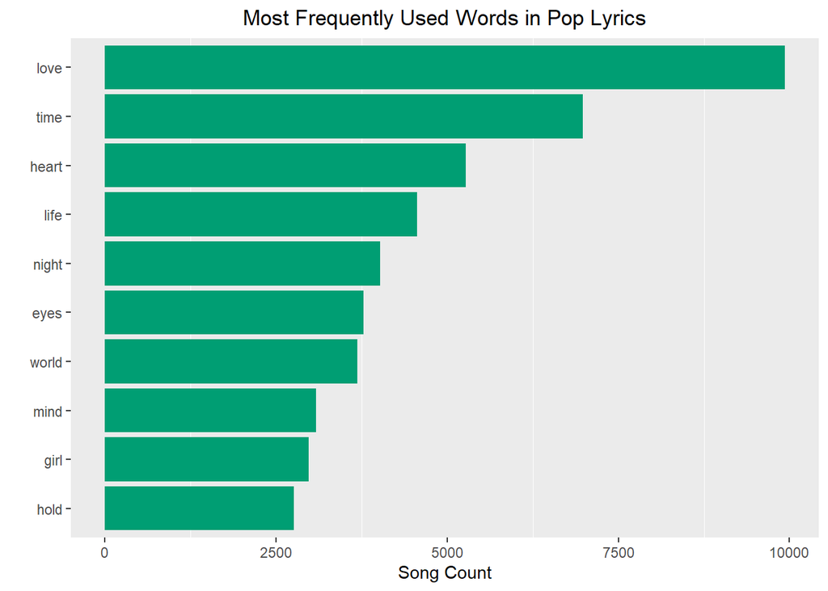

```r
#make a bar plot of the most frequently used 10 words in pop music
pop_words_filtered %>%
  count(word, sort = TRUE) %>%
  top_n(10) %>%
  ungroup() %>%
  mutate(word = reorder(word, n)) %>%
  ggplot() +
    geom_col(aes(word, n), fill = cbPalette[4]) +
    theme(legend.position = "none",
          plot.title = element_text(hjust = 0.5),
          panel.grid.major = element_blank()) +
    xlab("") +
    ylab("Song Count") +
    ggtitle("Most Frequently Used Words in Pop Lyrics") +
    coord_flip()
```

But we already knew that. Do the most frequently used words in pop music vary by decade?

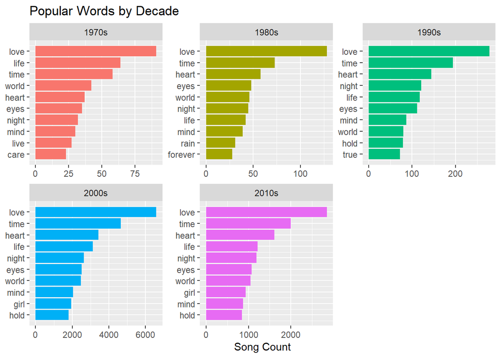

```r
#let's see if the most popular words change by decade
popular_words <- pop_words_filtered %>%
  group_by(decade) %>%
  count(word, decade, sort = TRUE) %>%
  slice(seq_len(10)) %>%
  ungroup() %>%
  arrange(decade,n) %>%
  mutate(row = row_number())

popular_words %>%
  ggplot(aes(row, n, fill = decade)) +
    geom_col(show.legend = NULL) +
    labs(x = NULL, y = "Song Count") +
    ggtitle("Popular Words by Decade") +
    facet_wrap(~decade, scales = "free") +
    scale_x_continuous(  # This handles replacement of row
      breaks = popular_words$row, # notice need to reuse data frame
      labels = popular_words$word) +
    coord_flip()
```

They do, but just barely. For the most part, the 10 most popular words remain the same for nearly 50 years. It’s worth noting that in the 1980s, *rain* finds its way into the top 10. Some popular songs about rain from the 80s include Prince’s *Purple Rain*, Guns ‘n Roses’ *November Rain*, Toto’s *Africa*, and *It’s Raining Men* by The Weather Girls.

There isn’t much more knowledge to be pulled out of the 10 most popular words, even when you look at a wordcloud.

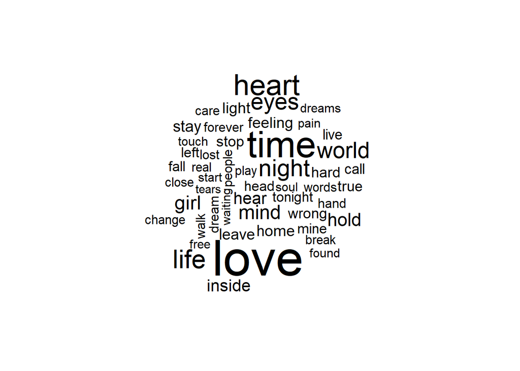

```r
library(wordcloud)
#wordcloud of most popular pop words
pop_words_filtered %>%
  anti_join(stop_words) %>%
  count(word) %>%
  with(wordcloud(word, n, max.words = 50))
```

```r
library(reshape2)
```

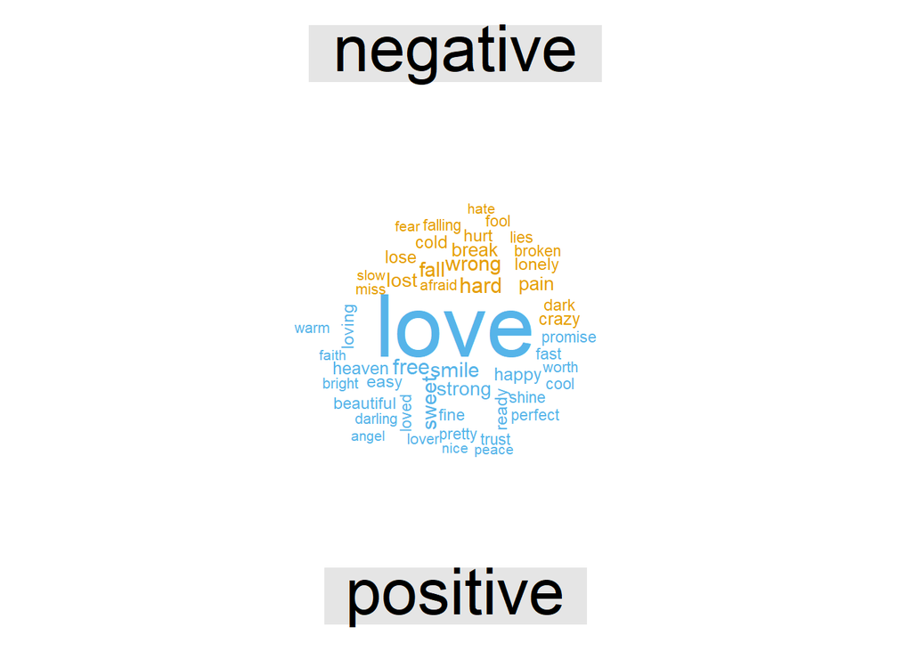

```r
#add sentiment analysis to the wordcloud
pop_words_filtered %>%
  inner_join(get_sentiments("bing")) %>%
  count(word, sentiment, sort = TRUE) %>%
  acast(word ~ sentiment, value.var = "n", fill = 0) %>%
  comparison.cloud(colors = c("#E69F00", "#56B4E9"),
                   max.words = 50)
```

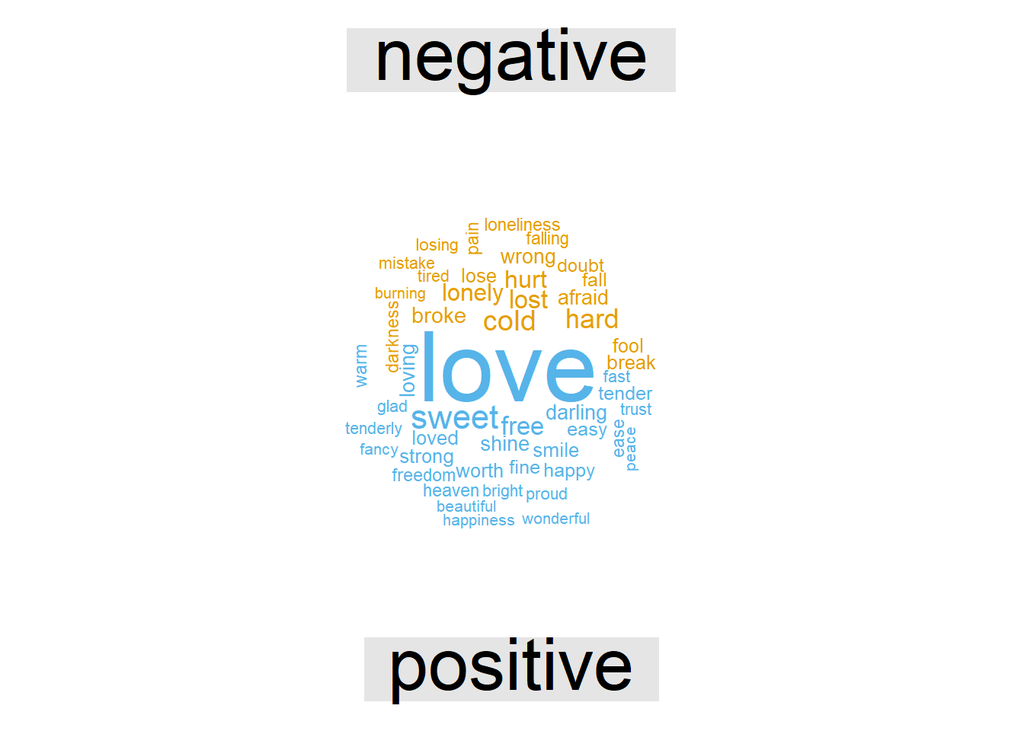

```r
#1970s sentiment word cloud
filtered_70s <- pop_words_filtered[which(pop_words_filtered$decade == "1970s"),]
filtered_70s %>%
  inner_join(get_sentiments("bing")) %>%
  count(word, sentiment, sort = TRUE) %>%
  acast(word ~ sentiment, value.var = "n", fill = 0) %>%
  comparison.cloud(colors = c("#E69F00", "#56B4E9"),
                   max.words = 50)
```

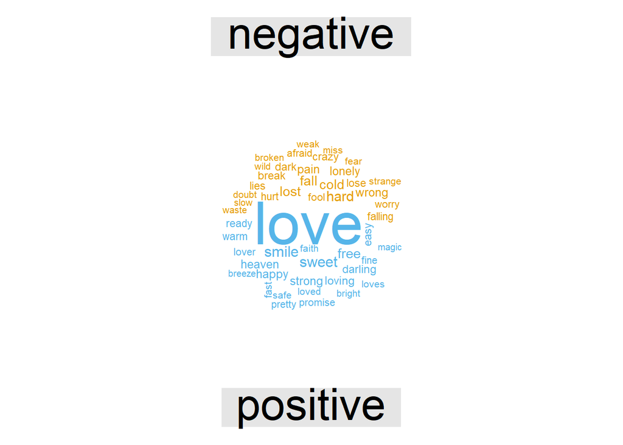

```r
#1990s sentiment word cloud
filtered_90s <- pop_words_filtered[which(pop_words_filtered$decade == "1990s"),]
filtered_90s %>%
  inner_join(get_sentiments("bing")) %>%
  count(word, sentiment, sort = TRUE) %>%
  acast(word ~ sentiment, value.var = "n", fill = 0) %>%
  comparison.cloud(colors = c("#E69F05", "#56B5E9"),
                   max.words = 50)
```

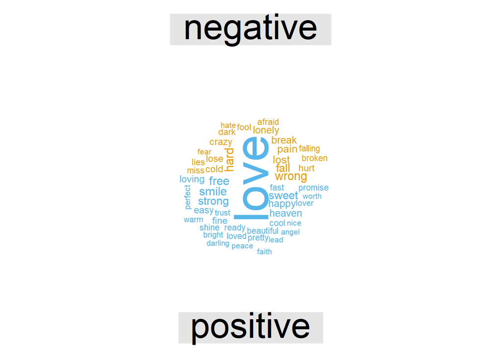

```r
#2000s sentiment word cloud
filtered_00s <- pop_words_filtered[which(pop_words_filtered$decade == "2000s"),]
filtered_00s %>%
  inner_join(get_sentiments("bing")) %>%
  count(word, sentiment, sort = TRUE) %>%
  acast(word ~ sentiment, value.var = "n", fill = 0) %>%
  comparison.cloud(colors = c("#E69F05", "#56B5E9"),
                   max.words = 50)
```

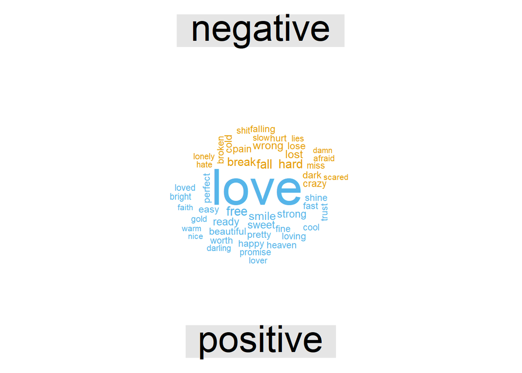

```r
#2010s sentiment word cloud
filtered_10s <- pop_words_filtered[which(pop_words_filtered$decade == "2010s"),]
filtered_10s %>%
  inner_join(get_sentiments("bing")) %>%
  count(word, sentiment, sort = TRUE) %>%
  acast(word ~ sentiment, value.var = "n", fill = 0) %>%
  comparison.cloud(colors = c("#E69F05", "#56B5E9"),
                   max.words = 50)
```

When you break this down by decade, it remains the same. Pop music is overwhelmingly positive and sappy.

But maybe it’s complicated in another way? Let’s see if they use long words, which are harder to rhyme with.

```r
pop_word_lengths <- lyrics_pop %>%
  unnest_tokens(word, lyrics) %>%
  group_by(song,decade) %>%
  distinct() %>%
  filter(!word %in% undesirable_words) %>%
  mutate(word_length = nchar(word))
```

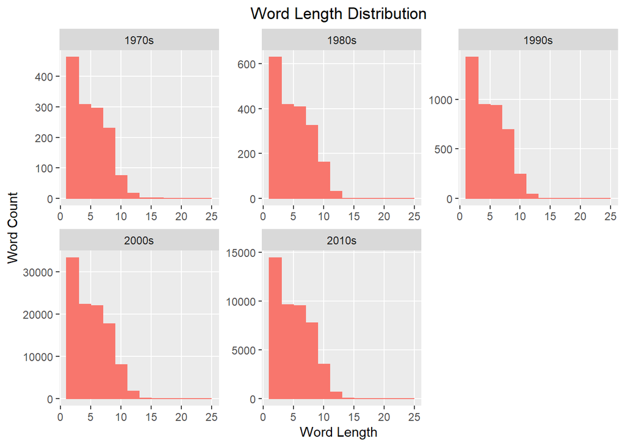

```r
#histogram of length of words over time
pop_word_lengths %>%
  count(word_length, sort = TRUE) %>%
  ggplot(aes(word_length),
         binwidth = 10) +
    geom_histogram(aes(color = "black", fill = "white"),
                   breaks = seq(1,25, by = 2),
                   show.legend = FALSE) +
    xlab("Word Length") +
    ylab("Word Count") +
    facet_wrap(~decade, scales = "free") +
    ggtitle("Word Length Distribution") +
    theme(plot.title = element_text(hjust = 0.5),
          panel.grid.minor = element_blank())
```

They don’t! The majority of words used in pop lyrics are less than 6 letters long, regardless of decade.

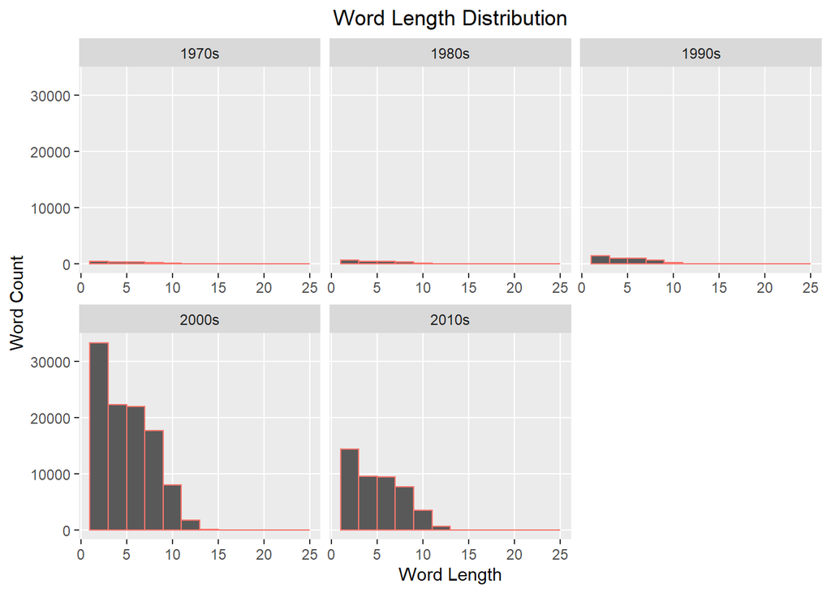

```r
#doesn't look like much of a change, but let's fix the y axis
pop_word_lengths %>%
  count(word_length, sort = TRUE) %>%
  ggplot(aes(word_length),
         binwidth = 10) +
    geom_histogram(aes(color = "black"),
                   breaks = seq(1,25, by = 2),
                   show.legend = FALSE) +
    xlab("Word Length") +
    ylab("Word Count") +
    facet_wrap(~decade, scales = "free_x") +
    ggtitle("Word Length Distribution") +
    theme(plot.title = element_text(hjust = 0.5),
          panel.grid.minor = element_blank())
```

But if you fix the Y axis of these histograms, you will see that the word count really jumped up in the 21st century.

```r
#let's see how many different words are used in a song
lex_diversity_per_year <- lyrics_pop %>%
  filter(decade != "NA") %>%
  unnest_tokens(word, lyrics) %>%
  group_by(song,year) %>%
  summarise(lex_diversity = n_distinct(word)) %>%
  arrange(desc(lex_diversity))

#and let's plot to see if that changes over time
diversity_plot <- lex_diversity_per_year %>%
  ggplot(aes(year, lex_diversity)) +
    geom_point(color = cbPalette[3],
               alpha = .4,
               size = 4,
               position = "jitter") +
    stat_smooth(color = "black", se = FALSE, method = "lm") +
    geom_smooth(aes(x = year, y = lex_diversity), se = FALSE,
                color = "blue", lwd = 2) +
    ggtitle("Lexical Diversity") +
    xlab("Time") +
    ylab("")
    scale_color_manual(values = cbPalette)
```

[output not shown]

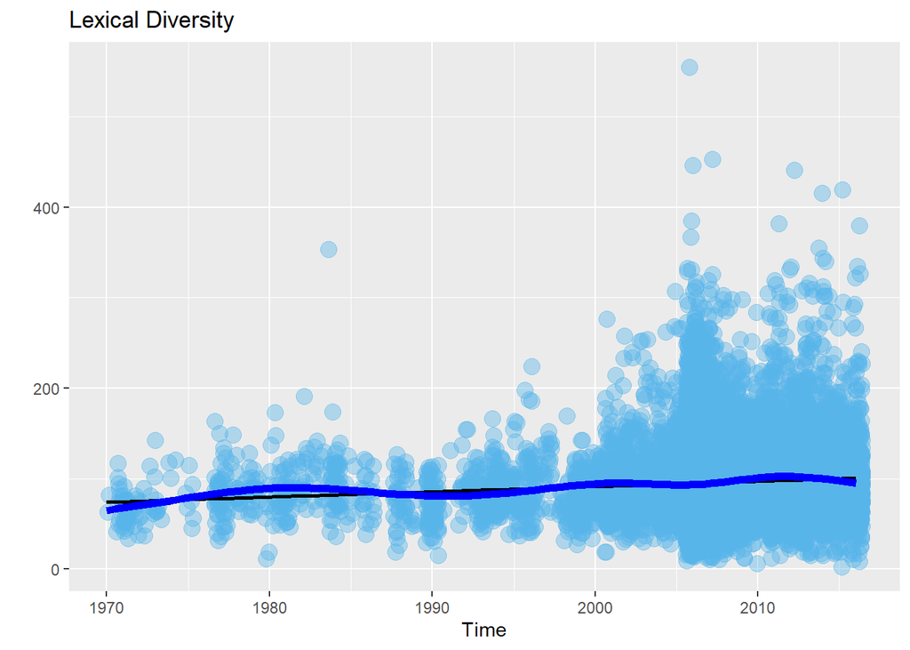

```r
diversity_plot
```

Maybe pop music is complicated because it uses a lot of *different* words? Let’s check the lexical diversity of pop lyrics over time.

One last attempt at finding complexity in pop music. Let’s look at the TF-IDF, which shows us the most important words.

```r
#find the important words in pop music by tf-idf
 popular_tfidf_words <- lyrics_pop %>%
  unnest_tokens(word, lyrics) %>%
  distinct() %>%
  filter(!word %in% undesirable_words) %>%
  filter(nchar(word) > 3) %>%
  count(decade, word, sort = TRUE) %>%
  ungroup() %>%
  bind_tf_idf(word, decade, n)
```

```r
#tidy
top_popular_tfidf_words <- popular_tfidf_words %>%
  arrange(desc(tf_idf)) %>%
  mutate(word = factor(word, levels = rev(unique(word)))) %>%
  group_by(decade) %>%
  slice(seq_len(8)) %>%
  ungroup() %>%
  arrange(decade, tf_idf) %>%
  mutate(row = row_number())
```

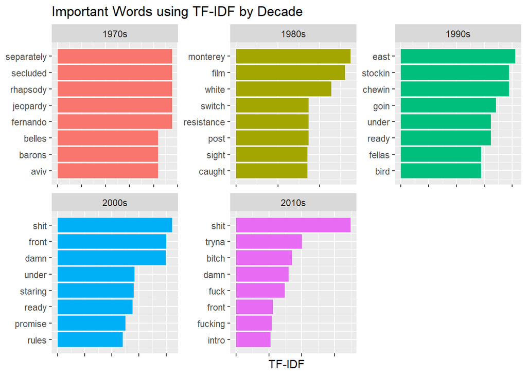

```r
#plot tf-idf by decade
top_popular_tfidf_words %>%
  ggplot(aes(x = row, tf_idf,
             fill = decade)) +
    geom_col(show.legend = NULL) +
    labs(x = NULL, y = "TF-IDF") +
    ggtitle("Important Words using TF-IDF by Decade") +
    facet_wrap(~decade, ncol = 3, scales = "free") +
    scale_x_continuous(
      breaks = top_popular_tfidf_words$row,
      labels = top_popular_tfidf_words$word) +
    theme(axis.text.x = element_blank()) +
    coord_flip()
```